# VLM-SAM3 Results — Jobs 465388 & 465389

**Job 465388** — EXP-C-box / EXP-C-box-cot (bbox localization approach)  
**Job 465389** — EXP-F-mf1 / mf3 / mf5 / mf10 (multiframe ablation)  
**Completed**: 2026-03-09

### What's new in these jobs

- **EXP-C-box**: VLM outputs a bounding box (x1,y1,x2,y2) instead of text. SAM3 uses it as a geometry prompt — bypasses the 32-token text encoder limit entirely.
- **EXP-F-mf{k}**: Ablation of how many source frames to show the VLM (1, 3, 5, 10). All use instruct model.
- **Critical fix**: Qwen3-VL outputs bounding boxes in 0-1000 normalized space. Previous jobs forgot to divide by 1000 → IoU=0 for all bbox pairs. Fixed in commit `ece420a`.

### Sections

1. Setup & data loading
2. Overall summary table (all experiments)
3. EXP-C-box deep dive: bbox parse rate, IoU distribution
4. EXP-C-box vs text baselines
5. Per-scenario breakdown (EXP-C-box)
6. Multiframe ablation (EXP-F)
7. Best/worst examples
8. Key findings

```python
from pathlib import Path

REPO_ROOT  = Path("/home/3164542/reluminati-research")
SCRIPT_DIR = REPO_ROOT / "src/scripts/experiments/vlm-sam3"

# All result files (deduplicated below)
RESULT_FILES = [
    SCRIPT_DIR / "results_463119.csv",
    SCRIPT_DIR / "results_465254.csv",
    SCRIPT_DIR / "results_465301.csv",
    SCRIPT_DIR / "results_465302.csv",
    SCRIPT_DIR / "results_465303.csv",
    SCRIPT_DIR / "results_465388.csv",   # EXP-C-box/cot  ← NEW
    SCRIPT_DIR / "results_465389.csv",   # EXP-F-mf1/3/5/10 ← NEW
]

BASELINE_CSV = Path("/data/video_datasets/3164542/baseline_multiframe_w10.csv")

# Experiments in each new job
BOX_EXPS = ["EXP-C-box", "EXP-C-box-cot"]
MF_EXPS  = ["EXP-F-mf1", "EXP-F-mf3", "EXP-F-mf5", "EXP-F-mf10"]
TEXT_BASELINES = ["EXP-C", "EXP-C-cot"]
ALL_TARGET_EXPS = TEXT_BASELINES + BOX_EXPS + MF_EXPS

LM_EEC_MEAN_IOU = 0.660   # exo→ego direction

print(f"Script dir  : {SCRIPT_DIR}")
print(f"Baseline    : {BASELINE_CSV}  exists={BASELINE_CSV.exists()}")
```

```
Script dir  : /home/3164542/reluminati-research/src/scripts/experiments/vlm-sam3
Baseline    : /data/video_datasets/3164542/baseline_multiframe_w10.csv  exists=True
```

```python
import warnings
import numpy as np
import pandas as pd
import matplotlib.pyplot as plt
import matplotlib.patches as mpatches
import seaborn as sns

warnings.filterwarnings("ignore")
plt.rcParams.update({"figure.figsize": (11, 5), "font.size": 11})
sns.set_theme(style="whitegrid", palette="husl")

EXP_PALETTE = {
    "EXP-C":          "#3498db",
    "EXP-C-cot":      "#e74c3c",
    "EXP-C-box":      "#f39c12",
    "EXP-C-box-cot":  "#e67e22",
    "EXP-F-mf1":      "#27ae60",
    "EXP-F-mf3":      "#16a085",
    "EXP-F-mf5":      "#2980b9",
    "EXP-F-mf10":     "#8e44ad",
}

EXP_LABELS = {
    "EXP-C":          "EXP-C\n(cloud,text)",
    "EXP-C-cot":      "EXP-C-cot\n(instruct,text)",
    "EXP-C-box":      "EXP-C-box\n(cloud,bbox)",
    "EXP-C-box-cot":  "EXP-C-box-cot\n(instruct,bbox)",
    "EXP-F-mf1":      "mf1\n(1 frame)",
    "EXP-F-mf3":      "mf3\n(3 frames)",
    "EXP-F-mf5":      "mf5\n(5 frames)",
    "EXP-F-mf10":     "mf10\n(10 frames)",
}

KEY_COLS = ["take_uid", "object_name", "src_camera", "dest_camera", "frame", "experiment"]
print("Imports OK.")
```

```
Imports OK.
```

## 1 Load & Deduplicate Data

```python
dfs = []
for f in RESULT_FILES:
    if f.exists():
        dfs.append(pd.read_csv(f, dtype=str))
        print(f"Loaded: {f.name}  ({len(dfs[-1])} rows)")
    else:
        print(f"SKIP (not found): {f.name}")

raw = pd.concat(dfs, ignore_index=True)
print(f"\nTotal before dedup : {len(raw):,}")

# Deduplicate: keep last (most recent job wins)
all_df = raw.drop_duplicates(subset=KEY_COLS, keep="last").copy()
print(f"Total after dedup  : {len(all_df):,}")

# Type coercion
all_df["iou"] = pd.to_numeric(all_df["iou"], errors="coerce")
all_df["success"] = all_df["iou"] > 0

print(f"\nExperiments present:")
print(all_df["experiment"].value_counts().to_string())
```

```
Loaded: results_463119.csv  (16732 rows)
```

```
Loaded: results_465254.csv  (17486 rows)
```

```
Loaded: results_465301.csv  (22656 rows)
```

```
Loaded: results_465302.csv  (23146 rows)
```

```
Loaded: results_465303.csv  (22656 rows)
```

```
Loaded: results_465388.csv  (25522 rows)
Loaded: results_465389.csv  (27898 rows)
```

```
Total before dedup : 156,096
```

```
Total after dedup  : 25,210

Experiments present:
experiment
EXP-F-mf5        2493
EXP-C-cot        2493
EXP-C            2493
EXP-C-box        1433
EXP-C-box-cot    1433
EXP-C-ctx-cot    1433
EXP-F-mf1        1433
EXP-C-ctx        1433
EXP-F-mf3        1433
EXP-F-mf10       1433
EXP-D-bbox       1100
EXP-A-vw5        1100
EXP-A            1100
EXP-B            1100
EXP-A-vw10       1100
EXP-E-crop       1100
EXP-A-cot        1100
```

## 2 Overall Summary Table

```python
def exp_stats(df, exp):
    g = df[df["experiment"] == exp].copy()
    iou = g["iou"].dropna()
    pos = iou[iou > 0]
    n = len(iou)
    return {
        "N":           n,
        "iou>0 %":     100 * len(pos) / max(1, n),
        "mean_all":    iou.mean(),
        "mean_pos":    pos.mean() if len(pos) else float("nan"),
        "iou>0.5 %":  100 * (pos > 0.5).mean() if len(pos) else 0,
        "iou>0.75 %": 100 * (pos > 0.75).mean() if len(pos) else 0,
    }

rows = []
for exp in ALL_TARGET_EXPS:
    s = exp_stats(all_df, exp)
    s["experiment"] = exp
    rows.append(s)

summ = pd.DataFrame(rows).set_index("experiment")

# Add LM-EEC baseline row for reference
lm_row = pd.DataFrame([{
    "N": "—", "iou>0 %": "—", "mean_all": 0.660,
    "mean_pos": 0.660, "iou>0.5 %": "—", "iou>0.75 %": "—"
}], index=["LM-EEC (exo→ego)"])

display_df = pd.concat([lm_row, summ])
print("Full results summary (deduplicated across all jobs):")
display(
    display_df.style
    .format({
        "mean_all":    "{:.3f}",
        "mean_pos":    "{:.3f}",
    }, na_rep="—")
    .background_gradient(subset=["iou>0 %"], cmap="RdYlGn")
    .background_gradient(subset=["mean_pos"], cmap="YlGn")
)
```

```
Full results summary (deduplicated across all jobs):
```

[output not shown]

[output cut: 79 more lines]

[output not shown]

```
<pandas.io.formats.style.Styler at 0x7f773d92fe20>
```

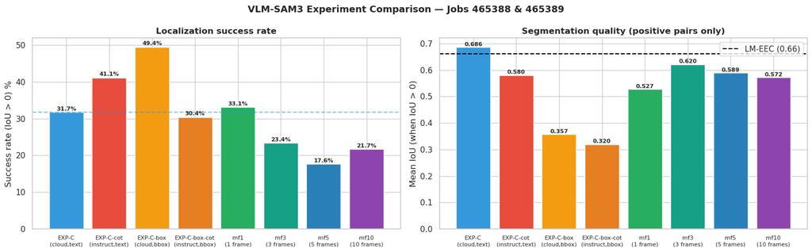

```python
fig, axes = plt.subplots(1, 2, figsize=(16, 5))

exps_to_plot = TEXT_BASELINES + BOX_EXPS + MF_EXPS

# --- success rate ---
ax = axes[0]
vals = [summ.loc[e, "iou>0 %"] for e in exps_to_plot]
colors = [EXP_PALETTE.get(e, "gray") for e in exps_to_plot]
bars = ax.bar([EXP_LABELS[e] for e in exps_to_plot], vals, color=colors, edgecolor="white")
ax.axhline(100 * (all_df[all_df["experiment"]=="EXP-C"]["success"].mean()),
           ls="--", color=EXP_PALETTE["EXP-C"], lw=1.5, alpha=0.6, label="EXP-C baseline")
for b, v in zip(bars, vals):
    ax.text(b.get_x() + b.get_width()/2, v + 0.5,
            f"{v:.1f}%", ha="center", fontsize=8, fontweight="bold")
ax.set_ylabel("Success rate (IoU > 0) %")
ax.set_title("Localization success rate", fontweight="bold")
ax.tick_params(axis="x", labelsize=8)

# --- mean IoU when positive ---
ax = axes[1]
vals2 = [summ.loc[e, "mean_pos"] for e in exps_to_plot]
bars2 = ax.bar([EXP_LABELS[e] for e in exps_to_plot], vals2, color=colors, edgecolor="white")
ax.axhline(LM_EEC_MEAN_IOU, ls="--", color="black", lw=1.5, label=f"LM-EEC ({LM_EEC_MEAN_IOU})")
for b, v in zip(bars2, vals2):
    if not np.isnan(v):
        ax.text(b.get_x() + b.get_width()/2, v + 0.005,
                f"{v:.3f}", ha="center", fontsize=8, fontweight="bold")
ax.set_ylabel("Mean IoU (when IoU > 0)")
ax.set_title("Segmentation quality (positive pairs only)", fontweight="bold")
ax.legend()
ax.tick_params(axis="x", labelsize=8)

plt.suptitle("VLM-SAM3 Experiment Comparison — Jobs 465388 & 465389",
             fontsize=13, fontweight="bold")
plt.tight_layout()
plt.show()
```

## 3 EXP-C-box Deep Dive: Bbox Parse Rate & IoU Distribution

The key question: when VLM outputs a bbox, does it produce a valid one? And when it does, what's the IoU?

```python
for exp in BOX_EXPS:
    g = all_df[all_df["experiment"] == exp].copy()
    iou = g["iou"].dropna()
    pos = iou[iou > 0]
    has_bbox = g["vlm_bbox"].notna() & (g["vlm_bbox"].astype(str) != "nan")
    not_vis  = (~has_bbox).sum()

    print(f"\n{'='*55}")
    print(f"  {exp}  ({len(g)} pairs)")
    print(f"{'='*55}")
    print(f"  VLM found bbox     : {has_bbox.sum()} ({100*has_bbox.mean():.1f}%)")
    print(f"  VLM said not_vis   : {not_vis} ({100*not_vis/max(1,len(g)):.1f}%)")
    print(f"  iou > 0            : {len(pos)}/{len(iou)} = {100*len(pos)/max(1,len(iou)):.1f}%")
    if len(pos):
        print(f"  mean IoU (pos)     : {pos.mean():.3f}   median: {pos.median():.3f}")
        print(f"  iou > 0.5          : {(pos>0.5).sum()} ({100*(pos>0.5).mean():.1f}%)")
        print(f"  iou > 0.75         : {(pos>0.75).sum()} ({100*(pos>0.75).mean():.1f}%)")
        print(f"  iou > 0.90         : {(pos>0.9).sum()} ({100*(pos>0.9).mean():.1f}%)")
```

```
=======================================================
  EXP-C-box  (1433 pairs)
=======================================================
  VLM found bbox     : 1129 (78.8%)
  VLM said not_vis   : 304 (21.2%)
  iou > 0            : 708/1433 = 49.4%
  mean IoU (pos)     : 0.357   median: 0.211
  iou > 0.5          : 252 (35.6%)
  iou > 0.75         : 151 (21.3%)
  iou > 0.90         : 50 (7.1%)

=======================================================
  EXP-C-box-cot  (1433 pairs)
=======================================================
  VLM found bbox     : 1225 (85.5%)
  VLM said not_vis   : 208 (14.5%)
  iou > 0            : 436/1433 = 30.4%
  mean IoU (pos)     : 0.320   median: 0.154
  iou > 0.5          : 138 (31.7%)
  iou > 0.75         : 80 (18.3%)
  iou > 0.90         : 34 (7.8%)
```

[figure not shown]

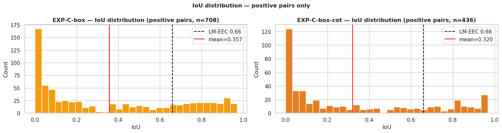

```python
fig, axes = plt.subplots(1, 2, figsize=(15, 5))

for ax, exp in zip(axes, BOX_EXPS):
    g = all_df[all_df["experiment"] == exp].copy()
    iou = g["iou"].dropna()
    pos = iou[iou > 0]
    not_vis = (~(g["vlm_bbox"].notna() & (g["vlm_bbox"].astype(str) != "nan"))).sum()

    # stacked bar: not_visible / failed_iou=0 / success
    iou_zero = (iou == 0).sum()
    ax.bar(["Pairs"], [not_vis],  color="#e74c3c", label="VLM: not visible")
    ax.bar(["Pairs"], [iou_zero], color="#f39c12",
           bottom=[not_vis], label="bbox found, IoU=0")
    ax.bar(["Pairs"], [len(pos)],  color="#2ecc71",
           bottom=[not_vis + iou_zero], label="IoU > 0")
    ax.set_title(f"{exp} — outcome breakdown\n(N={len(g)})", fontweight="bold")
    ax.set_ylabel("# pairs")
    ax.legend()

plt.suptitle("Bbox experiments: outcome breakdown", fontsize=12, fontweight="bold")
plt.tight_layout()
plt.show()

# IoU distribution for positive pairs
fig, axes = plt.subplots(1, 2, figsize=(15, 4))
for ax, exp in zip(axes, BOX_EXPS):
    pos = all_df[all_df["experiment"] == exp]["iou"]
    pos = pos[pos > 0].dropna()
    ax.hist(pos, bins=30, color=EXP_PALETTE[exp], edgecolor="white")
    ax.axvline(LM_EEC_MEAN_IOU, color="black", ls="--", label=f"LM-EEC {LM_EEC_MEAN_IOU}")
    ax.axvline(pos.mean(), color="red", ls="-", label=f"mean={pos.mean():.3f}")
    ax.set_xlabel("IoU")
    ax.set_ylabel("Count")
    ax.set_title(f"{exp} — IoU distribution (positive pairs, n={len(pos)})", fontweight="bold")
    ax.legend()
plt.suptitle("IoU distribution — positive pairs only", fontsize=12, fontweight="bold")
plt.tight_layout()
plt.show()
```

## 4 EXP-C-box vs Text Baselines

Two dimensions of comparison:

- **Localization rate** (iou>0%): how often does the approach find the object at all?
- **Segmentation quality** (mean IoU | success): when found, how precise is SAM3's mask?

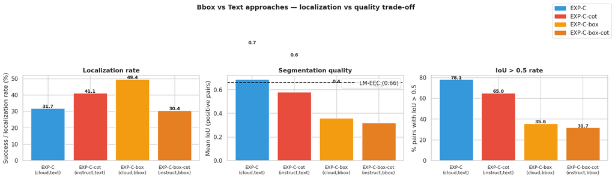

```
Key insight:
  EXP-C-box has HIGHER localization (49.4%) but LOWER quality (mean IoU=0.357)
  EXP-C (text) has LOWER localization (31.7%) but HIGHER quality (mean IoU=0.686 > LM-EEC)
  → The bottleneck is VLM localization, not SAM3 segmentation
```

```python
compare_exps = ["EXP-C", "EXP-C-cot", "EXP-C-box", "EXP-C-box-cot"]

fig, axes = plt.subplots(1, 3, figsize=(17, 5))
metrics = [
    ("iou>0 %",   "Success / localization rate (%)",  "Localization rate"),
    ("mean_pos",  "Mean IoU (positive pairs)",         "Segmentation quality"),
    ("iou>0.5 %", "% pairs with IoU > 0.5",           "IoU > 0.5 rate"),
]

for ax, (col, ylabel, title) in zip(axes, metrics):
    vals   = [summ.loc[e, col] for e in compare_exps]
    colors = [EXP_PALETTE[e] for e in compare_exps]
    bars = ax.bar([EXP_LABELS[e] for e in compare_exps], vals, color=colors, edgecolor="white")
    for b, v in zip(bars, vals):
        if not np.isnan(float(v)):
            ax.text(b.get_x() + b.get_width()/2, float(v) + 0.3,
                    f"{float(v):.1f}", ha="center", fontsize=9, fontweight="bold")
    if col == "mean_pos":
        ax.axhline(LM_EEC_MEAN_IOU, ls="--", color="black", lw=1.5, label=f"LM-EEC ({LM_EEC_MEAN_IOU})")
        ax.legend()
    ax.set_ylabel(ylabel)
    ax.set_title(title, fontweight="bold")
    ax.tick_params(axis="x", labelsize=9)

handles = [mpatches.Patch(color=EXP_PALETTE[e], label=e) for e in compare_exps]
fig.legend(handles=handles, loc="upper right", bbox_to_anchor=(1.0, 1.0))
plt.suptitle("Bbox vs Text approaches — localization vs quality trade-off",
             fontsize=13, fontweight="bold")
plt.tight_layout()
plt.show()

print("\nKey insight:")
print("  EXP-C-box has HIGHER localization (49.4%) but LOWER quality (mean IoU=0.357)")
print("  EXP-C (text) has LOWER localization (31.7%) but HIGHER quality (mean IoU=0.686 > LM-EEC)")
print("  → The bottleneck is VLM localization, not SAM3 segmentation")
```

## 5 Per-Scenario Breakdown (EXP-C-box)

```python
SCENARIOS = {
    "basketball": ["basketball", "hoop", "Basket"],
    "cooking":    ["knife", "pan", "bowl", "kettle", "plate", "board", "noodle",
                   "egg", "paper", "fork", "spoon", "mug", "strainer", "spatula", "spaghetti"],
    "health":     ["CPR", "dummy", "covid", "swab", "test cassette", "test device",
                   "antigen", "extraction", "solution tube", "test kit", "instruction manual"],
    "music":      ["piano", "sheet", "guitar"],
    "bike":       ["bike", "bicycle", "wrench", "socket", "pump", "tube",
                   "handlebar", "grip", "stand", "tire", "trolley"],
}

box_df = all_df[all_df["experiment"] == "EXP-C-box"].copy()

scenario_stats = []
for scenario, keywords in SCENARIOS.items():
    pattern = "|".join(keywords)
    mask = box_df["object_name"].str.contains(pattern, case=False, na=False)
    g = box_df[mask]
    if len(g) == 0:
        continue
    iou = g["iou"].dropna()
    pos = iou[iou > 0]
    scenario_stats.append({
        "scenario":   scenario,
        "n":          len(g),
        "iou>0 %":    100 * len(pos) / max(1, len(iou)),
        "mean_pos":   pos.mean() if len(pos) else float("nan"),
        "iou>0.5 %": 100 * (pos > 0.5).mean() if len(pos) else 0,
    })

scen_df = pd.DataFrame(scenario_stats).set_index("scenario")
print("EXP-C-box — per-scenario breakdown:")
display(scen_df.style
    .format({"iou>0 %": "{:.1f}%", "mean_pos": "{:.3f}", "iou>0.5 %": "{:.1f}%"})
    .background_gradient(subset=["iou>0 %"], cmap="RdYlGn")
)
```

```
EXP-C-box — per-scenario breakdown:
```

| scenario | n | iou>0 % | mean_pos | iou>0.5 % |
| --- | --- | --- | --- | --- |
| basketball | 170 | 71.2% | 0.432 | 38.0% |
| cooking | 407 | 44.7% | 0.299 | 31.9% |
| health | 423 | 46.3% | 0.420 | 42.9% |
| music | 32 | 96.9% | 0.509 | 58.1% |
| bike | 277 | 58.1% | 0.261 | 23.0% |

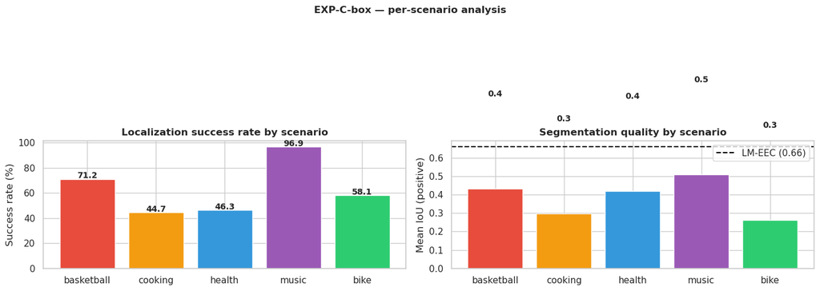

```python
SCENARIO_COLORS = {
    "basketball": "#e74c3c",
    "cooking":    "#f39c12",
    "health":     "#3498db",
    "music":      "#9b59b6",
    "bike":       "#2ecc71",
}

fig, axes = plt.subplots(1, 2, figsize=(14, 5))

for ax, col, ylabel, title in [
    (axes[0], "iou>0 %",  "Success rate (%)",      "Localization success rate by scenario"),
    (axes[1], "mean_pos", "Mean IoU (positive)",   "Segmentation quality by scenario"),
]:
    vals   = scen_df[col]
    colors = [SCENARIO_COLORS.get(s, "gray") for s in vals.index]
    bars   = ax.bar(vals.index, vals.values, color=colors, edgecolor="white")
    for b, v in zip(bars, vals.values):
        if not np.isnan(float(v)):
            ax.text(b.get_x() + b.get_width()/2, float(v) + 0.5,
                    f"{float(v):.1f}", ha="center", fontsize=10, fontweight="bold")
    if col == "mean_pos":
        ax.axhline(LM_EEC_MEAN_IOU, ls="--", color="black", lw=1.5,
                   label=f"LM-EEC ({LM_EEC_MEAN_IOU})")
        ax.legend()
    ax.set_ylabel(ylabel)
    ax.set_title(title, fontweight="bold")

plt.suptitle("EXP-C-box — per-scenario analysis", fontsize=12, fontweight="bold")
plt.tight_layout()
plt.show()
```

## 6 Multiframe Ablation (EXP-F)

How many source frames should we show the VLM? Ablation: 1, 3, 5, 10 frames.

All EXP-F experiments use the instruct model (235b-instruct) with text output.

```python
mf_stats = []
for exp in MF_EXPS:
    g = all_df[all_df["experiment"] == exp].copy()
    iou = g["iou"].dropna()
    pos = iou[iou > 0]
    miss = (g["vlm_output"].isna() | (g["vlm_output"].astype(str).str.strip() == "")).sum()
    mf_stats.append({
        "experiment":   exp,
        "n_frames":     int(exp.replace("EXP-F-mf", "")),
        "N":            len(iou),
        "iou>0 %":      100 * len(pos) / max(1, len(iou)),
        "mean_pos":     pos.mean() if len(pos) else float("nan"),
        "iou>0.5 %":   100 * (pos > 0.5).mean() if len(pos) else 0,
        "iou>0.75 %":  100 * (pos > 0.75).mean() if len(pos) else 0,
        "missing_vlm": miss,
    })

mf_df = pd.DataFrame(mf_stats).set_index("experiment")
print("Multiframe ablation results:")
display(mf_df.style
    .format({"iou>0 %": "{:.1f}%", "mean_pos": "{:.3f}",
             "iou>0.5 %": "{:.1f}%", "iou>0.75 %": "{:.1f}%"})
    .background_gradient(subset=["iou>0 %"], cmap="RdYlGn")
    .background_gradient(subset=["mean_pos"], cmap="YlGn")
)
```

```
Multiframe ablation results:
```

| experiment | n_frames | N | iou>0 % | mean_pos | iou>0.5 % | iou>0.75 % | missing_vlm |
| --- | --- | --- | --- | --- | --- | --- | --- |
| EXP-F-mf1 | 1 | 1433 | 33.1% | 0.527 | 58.6% | 49.4% | 0 |
| EXP-F-mf3 | 3 | 1433 | 23.4% | 0.620 | 69.9% | 57.9% | 0 |
| EXP-F-mf5 | 5 | 2493 | 17.6% | 0.589 | 66.4% | 56.8% | 223 |
| EXP-F-mf10 | 10 | 1433 | 21.7% | 0.572 | 65.0% | 55.3% | 0 |

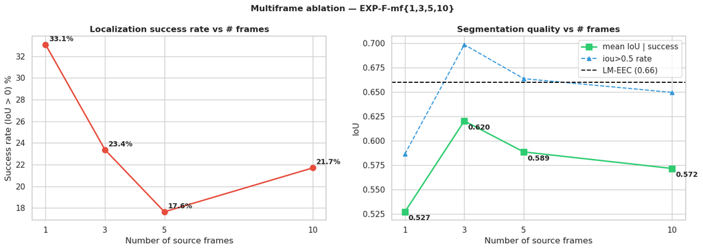

[output not shown]

```python
fig, axes = plt.subplots(1, 2, figsize=(14, 5))

x = mf_df["n_frames"]

# Success rate vs n_frames
ax = axes[0]
ax.plot(x, mf_df["iou>0 %"], "o-", color="#e74c3c", lw=2, ms=8, label="iou>0 %")
ax.set_xlabel("Number of source frames")
ax.set_ylabel("Success rate (IoU > 0) %")
ax.set_title("Localization success rate vs # frames", fontweight="bold")
ax.set_xticks([1, 3, 5, 10])
for xi, yi in zip(x, mf_df["iou>0 %"]):
    ax.annotate(f"{yi:.1f}%", (xi, yi), textcoords="offset points",
                xytext=(5, 5), fontsize=10, fontweight="bold")

# Quality vs n_frames
ax = axes[1]
ax.plot(x, mf_df["mean_pos"], "s-", color="#2ecc71", lw=2, ms=8, label="mean IoU | success")
ax.plot(x, mf_df["iou>0.5 %"] / 100, "^--", color="#3498db", lw=1.5, ms=6, label="iou>0.5 rate")
ax.axhline(LM_EEC_MEAN_IOU, ls="--", color="black", lw=1.5, label=f"LM-EEC ({LM_EEC_MEAN_IOU})")
ax.set_xlabel("Number of source frames")
ax.set_ylabel("IoU")
ax.set_title("Segmentation quality vs # frames", fontweight="bold")
ax.set_xticks([1, 3, 5, 10])
ax.legend()
for xi, yi in zip(x, mf_df["mean_pos"]):
    ax.annotate(f"{yi:.3f}", (xi, yi), textcoords="offset points",
                xytext=(5, -12), fontsize=10, fontweight="bold")

plt.suptitle("Multiframe ablation — EXP-F-mf{1,3,5,10}",
             fontsize=12, fontweight="bold")
plt.tight_layout()
plt.show()

print("\nKey observation:")
print("  Fewer frames → better localization rate (mf1=33.1% >> mf5=17.6%)")
print("  3 frames → best quality when found (mean_pos=0.620)")
print("  More context images appear to confuse the VLM's localization")
```

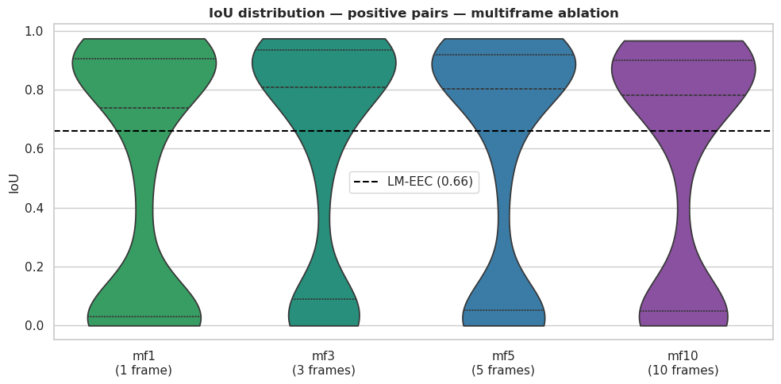

```python
mf_data = all_df[all_df["experiment"].isin(MF_EXPS)].copy()
mf_data = mf_data[mf_data["iou"] > 0]  # positive pairs only

fig, ax = plt.subplots(figsize=(10, 5))
sns.violinplot(
    data=mf_data, x="experiment", y="iou",
    order=MF_EXPS,
    palette={e: EXP_PALETTE[e] for e in MF_EXPS},
    inner="quartile", cut=0, ax=ax
)
ax.axhline(LM_EEC_MEAN_IOU, ls="--", color="black", lw=1.5, label=f"LM-EEC ({LM_EEC_MEAN_IOU})")
ax.set_xlabel("")
ax.set_xticklabels([EXP_LABELS[e] for e in MF_EXPS])
ax.set_ylabel("IoU")
ax.set_title("IoU distribution — positive pairs — multiframe ablation", fontweight="bold")
ax.legend()
plt.tight_layout()
plt.show()
```

## 7 Best & Worst Examples (EXP-C-box)

```python
box_all = all_df[all_df["experiment"] == "EXP-C-box"].copy()

print("TOP-10 IoU pairs (EXP-C-box):")
top10 = box_all.nlargest(10, "iou")[
    ["object_name", "take_uid", "frame", "vlm_bbox", "iou"]
]
for _, r in top10.iterrows():
    print(f"  [{r['object_name']:30s}]  bbox={str(r['vlm_bbox'])[:30]}  iou={float(r['iou']):.3f}")

print("\nBOTTOM-10 (IoU>0, EXP-C-box):")
pos = box_all[box_all["iou"] > 0]
bot10 = pos.nsmallest(10, "iou")[["object_name", "take_uid", "frame", "vlm_bbox", "iou"]]
for _, r in bot10.iterrows():
    print(f"  [{r['object_name']:30s}]  bbox={str(r['vlm_bbox'])[:30]}  iou={float(r['iou']):.4f}")
```

```
TOP-10 IoU pairs (EXP-C-box):
  [plastic container of sugar_0  ]  bbox=402.8,167.1,543.7,302.4  iou=0.970
  [noodles package_1             ]  bbox=400.4,324.4,460.1,401.4  iou=0.969
  [noodles package_1             ]  bbox=400.4,324.4,460.1,401.4  iou=0.968
  [noodles package_1             ]  bbox=400.4,324.4,460.1,401.4  iou=0.966
  [piano                         ]  bbox=256.3,130.4,451.3,428.7  iou=0.963
  [bowl of milk_0                ]  bbox=323.2,100.4,441.0,222.7  iou=0.955
  [CPR dummy                     ]  bbox=260.3,267.5,386.9,343.2  iou=0.950
  [CPR dummy                     ]  bbox=260.3,267.5,386.9,343.2  iou=0.950
  [CPR dummy                     ]  bbox=260.3,267.5,386.9,343.2  iou=0.949
  [CPR dummy                     ]  bbox=260.3,267.5,386.9,343.2  iou=0.948

BOTTOM-10 (IoU>0, EXP-C-box):
  [socket wrench_1               ]  bbox=345.5,78.8,561.2,212.8  iou=0.0001
  [socket wrench_1               ]  bbox=374.1,80.6,545.3,215.0  iou=0.0001
  [socket wrench_0               ]  bbox=161.6,167.1,308.1,316.7  iou=0.0002
  [socket wrench_0               ]  bbox=161.6,167.1,308.1,316.7  iou=0.0003
  [socket wrench_0               ]  bbox=161.6,167.1,308.1,316.7  iou=0.0004
  [socket wrench_0               ]  bbox=161.6,167.1,308.1,316.7  iou=0.0004
  [noodles package_1             ]  bbox=413.9,316.3,465.7,397.4  iou=0.0004
  [metal bowl_0                  ]  bbox=384.5,228.9,441.0,261.6  iou=0.0007
  [bicycle tire tube_0           ]  bbox=413.9,277.8,473.6,297.9  iou=0.0007
  [basketball                    ]  bbox=448.9,47.9,499.9,81.1  iou=0.0008
```

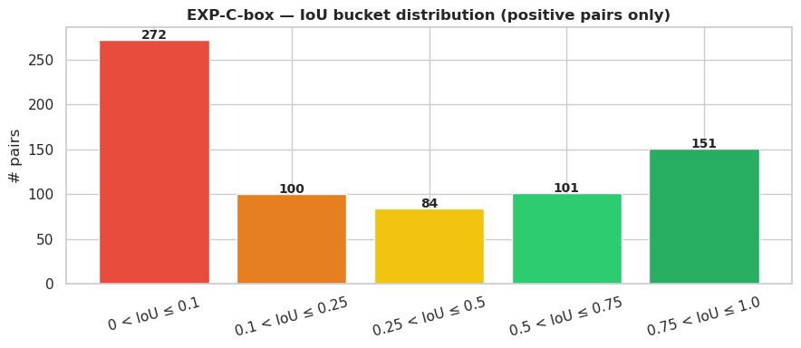

```
Total positive pairs: 708
  0 < IoU ≤ 0.1            :  272 (38.4%)
  0.1 < IoU ≤ 0.25         :  100 (14.1%)
  0.25 < IoU ≤ 0.5         :   84 (11.9%)
  0.5 < IoU ≤ 0.75         :  101 (14.3%)
  0.75 < IoU ≤ 1.0         :  151 (21.3%)
```

```python
# IoU bucket analysis
box_pos = box_all[box_all["iou"] > 0]["iou"].dropna()

buckets = {
    "0 < IoU ≤ 0.1":  ((box_pos > 0) & (box_pos <= 0.1)).sum(),
    "0.1 < IoU ≤ 0.25": ((box_pos > 0.1) & (box_pos <= 0.25)).sum(),
    "0.25 < IoU ≤ 0.5":  ((box_pos > 0.25) & (box_pos <= 0.5)).sum(),
    "0.5 < IoU ≤ 0.75":  ((box_pos > 0.5) & (box_pos <= 0.75)).sum(),
    "0.75 < IoU ≤ 1.0":  (box_pos > 0.75).sum(),
}

fig, ax = plt.subplots(figsize=(9, 4))
colors = ["#e74c3c", "#e67e22", "#f1c40f", "#2ecc71", "#27ae60"]
bars = ax.bar(buckets.keys(), buckets.values(), color=colors, edgecolor="white")
for b, v in zip(bars, buckets.values()):
    ax.text(b.get_x() + b.get_width()/2, v + 1,
            str(v), ha="center", fontsize=10, fontweight="bold")
ax.set_ylabel("# pairs")
ax.set_title("EXP-C-box — IoU bucket distribution (positive pairs only)", fontweight="bold")
ax.tick_params(axis="x", rotation=15)
plt.tight_layout()
plt.show()

total_pos = len(box_pos)
print(f"Total positive pairs: {total_pos}")
for k, v in buckets.items():
    print(f"  {k:25s}: {v:4d} ({100*v/total_pos:.1f}%)")
```